# Stop Data Analysis

Mengyu Li

July 29, 2016

### About the Berkeley PD Stop Data

The Berkeley PD stop data reflects accidents that have been visited by the Berkeley Police Department. Raw data set is downloaded from City of Berkeley Open Data website and provided by Berkeley Police Department.

Analysis in this part focuses on the information provided by the dispositions variable. The dispositions variable can be divided into three types. The first type only includes more than one six-character person message. Each character in each person message represents the race, gender and age range of the person, reason and enforcement of the stop, and the car search information during the stop. The second type of the dispositions includes only additional dispositions, such as P for primary cases. The third type of dispositions includes both person information and additional dispositions.

For the analysis in this part, only person information for all the people in each incident and the Call Time/Date of each incident are analyzed.

### Introduction

| items | count | percentage |
| --- | --- | --- |
| total incidents reported | 16255 |  |
| dispositions of type one | 13016 | 80.07% |
| dispositions of type two | 2346 | 14.43% |
| dispositions of type three | 845 | 5.20% |
| blank dispositions | 48 | 0.30% |
| incidents with person information | 13861 | 85.27% |
| incidents with 1 person | 13494 | 97.352% |
| incidents with 2 people | 322 | 2.323% |
| incidents with 3 people | 33 | 0.238% |
| incidents with 4 people | 6 | 0.043% |
| incidents with 5 people | 6 | 0.043% |
| total personnel reported | 14291 |  |

### Analysis of Race

#### Table: count of person recorded in each race

| Race | Count | 0-18 | 18-29 | 30-39 | 40+ |
| --- | --- | --- | --- | --- | --- |
| A | 1141 | 8.50% | 43.47% | 21.03% | 26.99% |
| B | 4636 | 2.29% | 34.97% | 25.09% | 37.66% |
| H | 1676 | 3.22% | 46.12% | 29.18% | 21.47% |
| O | 1384 | 2.67% | 43.28% | 29.17% | 26.87% |
| W | 5454 | 1.72% | 29.45% | 25.39% | 43.44% |

#### Picture: count of person recorded of each race in each hour

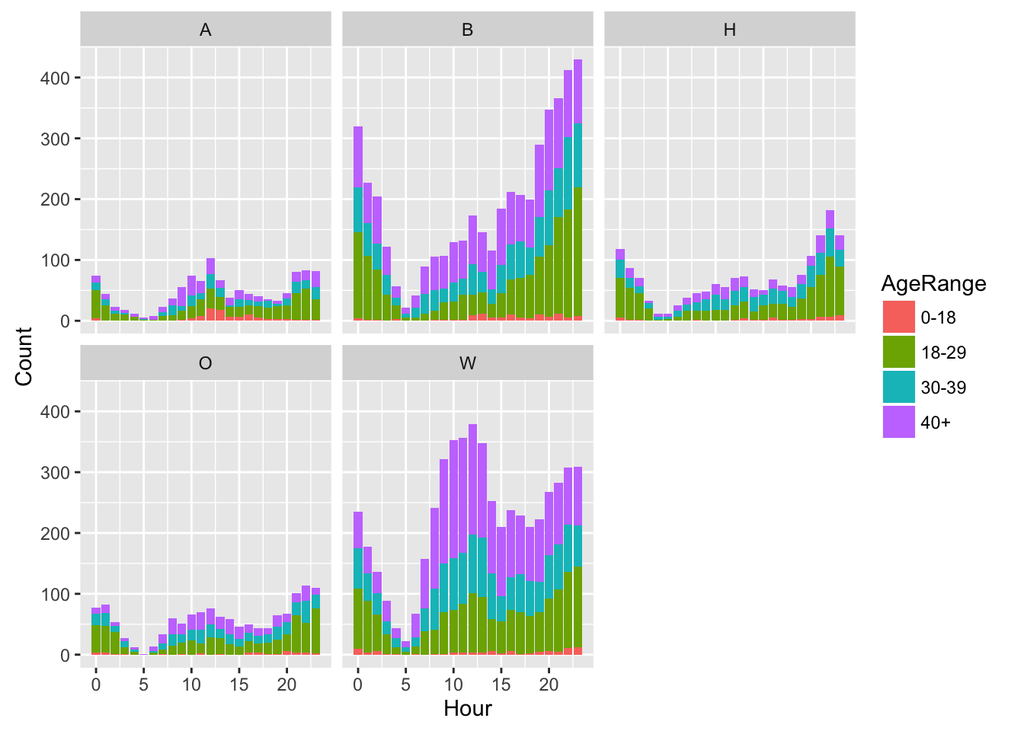

story: Comparing to any other race, Asian people contributes the lowest percentage of the incidents. This corresponds to the “model-minority” stereotype of the Asian poeple - seldom causing incidents. In addition, top 2 races of causing incidents are Black and White. This fact also makes sense - the majority of race of Berkeley residents is black and white.

The percentage of people aged from 0 to 18 of each race is less than 9%. People aged from 0 to 18 contributes the smallest percentage in each race. A reason for this fact is that young teenager contributes minority of the population of Berkeley. And we can also induce that Berkeley teenger eduation is qualified.

The percentage of people aged from 18 to 29 of each race is about or greater than 30, which is a important factor. One reason for this fact is that Bekeley is a university town. Most university students(undergraduates, master and PhD students) are aged from 18 to 29. Therefore, the ratio of people aged from 18 to 29 to all the residents in Berkeley should be greater than the average ratio of other cities in the US. Another reason is that young people maybe more impulsive to cause an incidents. The fact that quite a few of incidents are caused by people aged from 18 to 29 is reasonable here at Berkeley. Another interesting fact about people aged from 18 to 29 is that they contributes a majority of incidents at night. A reason for this fact is that these people are more liable to stay up late or all night and enjoy their nightlife outside and cause incidents.

### Analysis of Day

| Day | Count | A | B | H | O | W |
| --- | --- | --- | --- | --- | --- | --- |
| 1 | 1692 | 116 | 653 | 221 | 159 | 543 |
| 2 | 1665 | 149 | 543 | 182 | 166 | 625 |
| 3 | 2344 | 189 | 645 | 231 | 236 | 1043 |
| 4 | 2287 | 206 | 616 | 251 | 244 | 970 |
| 5 | 1941 | 152 | 592 | 223 | 168 | 806 |
| 6 | 2231 | 186 | 764 | 268 | 203 | 810 |
| 7 | 2131 | 143 | 823 | 300 | 208 | 657 |

1. Among all the day in a week, the number of incidents happened on Monday are much less than those happened through Tuesday and Saturday.
2. The count of records of Asian people is much less than that of any other race of people in each day and the whole week.
3. Asian people are less liable to commit an incident on Sunday, and more liable to commit an incident on Wednesday.
4. Black and Hispanic people are less liable to commit an incident on Monday, and more liable to commit an incident on Saturday.
5. White people are less liable to commit an incident on Sunday, and more liable to commit an incident on Tuesday and Wednesday, which is similar to Asian people.

An interesting fact is that number of incidents on Sunday is much more less than other 5 days in a week also. There are two guess for this fact: The first reason is that part of people tend to rest at home on Sunday, so these people reduce the amount of incidents happened on Sunday. (A senerio fits for the reason is that you can seldom see large amount of people on Berkeley campus on Sunday.) The second reason is that the police may want to rest on Sunday, so the number of policemen working on Sunday is less. Therefore, the Berkeley Police Department stop for less incidents on Sunday.

Another interesing fact is that the number of incidents happened on Friday and Saturday is high. A reasonable deduction of the fact is that people tend to participate some entertainment activities on the weekends, so the additional activities increase the probability of causing an error.

### Analysis of incidents of each hour in a day

#### Table: count of person recorded in each hour in a day

| Hour | Count | Hour | Count | Hour | Count | Hour | Count |
| --- | --- | --- | --- | --- | --- | --- | --- |
| 0 | 823 | 6 | 157 | 12 | 802 | 18 | 544 |
| 1 | 618 | 7 | 341 | 13 | 695 | 19 | 685 |
| 2 | 489 | 8 | 489 | 14 | 515 | 20 | 834 |
| 3 | 289 | 9 | 582 | 15 | 542 | 21 | 971 |
| 4 | 135 | 10 | 682 | 16 | 612 | 22 | 1098 |
| 5 | 61 | 11 | 678 | 17 | 578 | 23 | 1071 |

1. time span of 22:00 to 22:59 in a day has the highest incidents count, and 23:00 to 23:59 has the second highest, which means that Berkeley area is most dangerous from 10pm to 12am in a day, which corresponds to daily life experience.
2. From 12am to 5am, incidents count decreases gradually. A reasonable conjecture of this fact is that more and more people choose to sleep as time goes by in this time span. For the similar reason, incidents count increases gradually from 5am to 11am.
3. After the evening until the midnight, the incidents number increases gradually again in a day. The tally of the statistics and observation in daily life is in a good agreement.

#### Picture: Probability of BPD stop for a specific age range in a specific hour

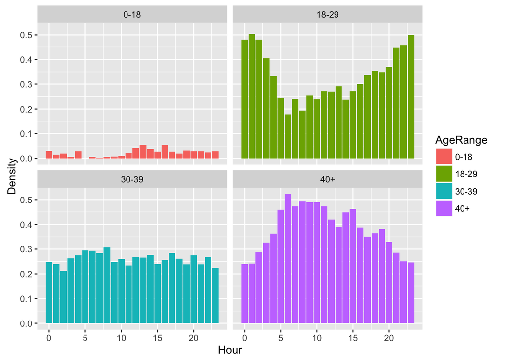

1. People aged from 18 to 29 are obviously liable to commit incidents at night. The average ratio of people aged from 18 to 29 to all people stoped by the Berkeley Police Department at night is greater than 40%.
2. People aged greater than 40 are obviously liable to commit incidents in the daytime. The average ratio of people aged greater than 40 to all people stoped by the Berkeley Police Deparment during the day is greater than 40%.
3. Ratio of incidents commited by people aged between 0 and 18 and people aged from 30 to 39 fluctuates during the daytime and the night, with an average ratio of 2.5% and 25% respectively.

#### Probability of BPD stop for a specific race in a specific hour

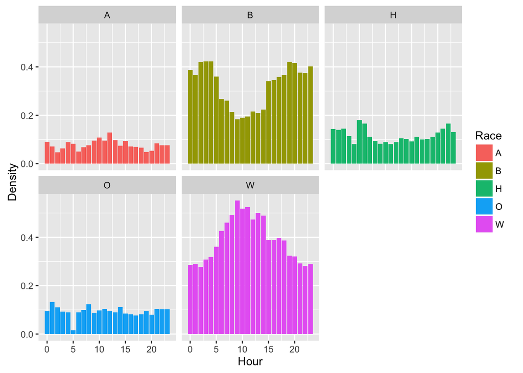

1. Black people are obviously liable to commit incidents at night. The average ratio of black people to all people stoped by the Berkeley Police Department at night is about 40%.
2. White people are obviously liable to commit incidents in the daytime. The average ratio of white people to all people stoped by the Berkeley Police Deparment during the day is about 45%.
3. Ratio of incidents commited by Asian people, Hispanic people and other people fluctuate during the daytime and the night, with an average ratio of 8%, 11% and 9% respectively.

### Analysis of prefence of Berkeley Police Department arresting people

#### Picture: Probability of arrested by BPD of a specific race for a specific reason

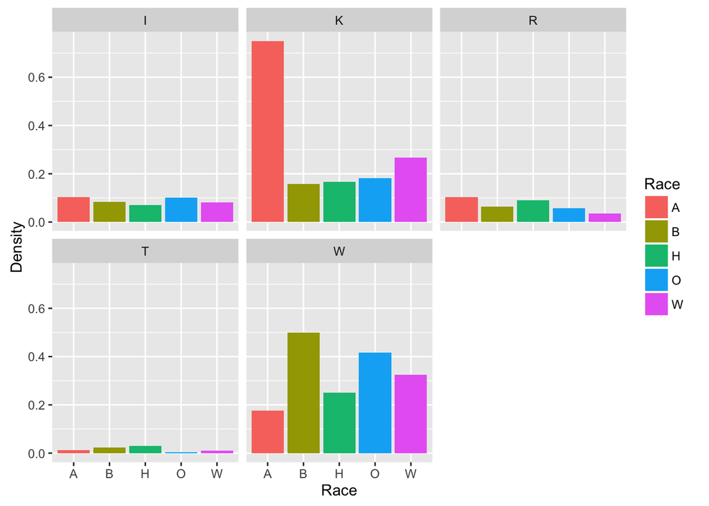

#### Table: Probability of arrested by BPD of a specific race for a specific reason

| P | I | K | R | T | W |
| --- | --- | --- | --- | --- | --- |
| A | 10.34% | 75% | 10.34% | 1.24% | 17.60% |
| B | 8.31% | 15.79% | 6.44% | 2.28% | 50.00% |
| H | 6.98% | 16.67% | 9.09% | 2.90% | 25.00% |
| O | 10.14% | 18.18% | 5.80% | 0.41% | 41.67% |
| W | 8.14% | 26.79% | 3.40% | 1.04% | 32.56% |

Note: in the picture and table above, I for Investigation, T for Traffic, R for Reasonable Suspicion, K for Probation/Parole, W for wanted.

1. The probability of arrested in a stop with the reason Traffic is much lower than other reasons. The average conditional probability of arrested given reason is traffic is 1.58%.
2. The probability of arrested in a stop with the reason Wanted is much higher than other reason. The average conditional probability of arrested given reason is wanted is 33.33%.
3. An interesting fact is that the conditional probability of arrested in a stop with the reason Probation or Parole and race Asian is 75%, which is much higher than that of any other race. Asian people is much more liable to be arrested by Berkeley Police Department during Probation or Parole if stopped by the BPD.

#### Picture: Probability of arrested by BPD of a specific age range for a specific reason

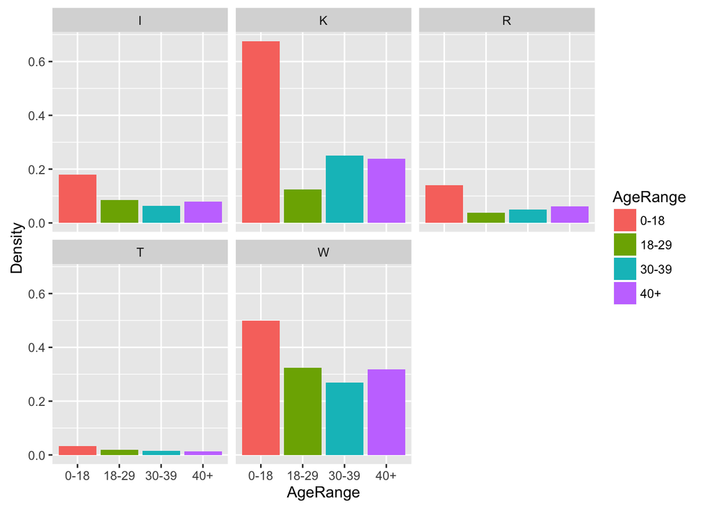

#### Table: Probability of arrested by BPD of a specific age range for a specific reason

| P | I | K | R | T | W |
| --- | --- | --- | --- | --- | --- |
| 0-18 | 17.95% | 67.57% | 13.95% | 3.24% | 50.00% |
| 18-29 | 8.45% | 12.50% | 3.87% | 1.82% | 32.35% |
| 30-39 | 6.32% | 25.00% | 5.04% | 1.49% | 26.92% |
| 40+ | 7.87% | 23.86% | 6.13% | 1.41% | 31.82% |

1. Similar to the conclusions above, the probability of arrested in a stop with the reason Traffic is the lowest and wanted is the highest.
2. Again similar to the conclusion above, an interesting fact is that the conditional probability of arrested in a stop with the reason Probation or Parole and age range 0-18 is 67.56%, which is much higher than that of any other age range.
3. The conditional probability of arrested given person involved aged from 0 to 18 in a stop given any reason is more than that of given person with any other age range. Therefore, in a stop, teenagers is more liable to be arrested by Berkeley Police Department.

#### Picture: Probability of arrested by BPD of a specific gender for a specific reason

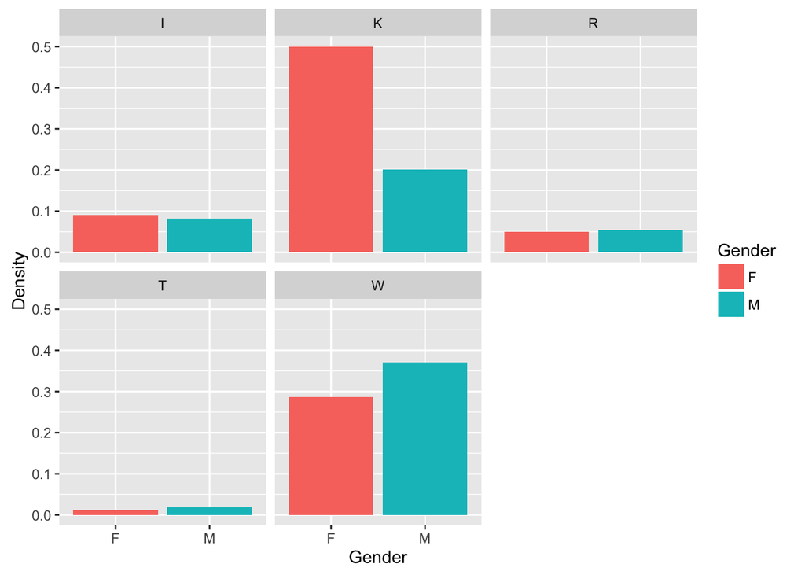

#### Table: Probability of arrested by BPD of a specific gender range for a specific reason

| P | I | K | R | T | W |
| --- | --- | --- | --- | --- | --- |
| F | 9.05% | 50.00% | 5.00% | 1.10% | 28.57% |
| M | 8.26% | 20.11% | 5.42% | 1.85% | 37.04% |